# NYT Crosswords Analysis

Angelina Sassi

5/11/2021

```r
#library(reticulate)
#source_python("fetch_puzzle_stats_as.py")
```

I’ve been playing the New York Times crossword consistently since July 2019, and I think I’m improving over time. I downloaded my NYT Crossword data thanks to [this code developed by Matt Dodge (thanks, Matt!)](https://github.com/mattdodge/nyt-crossword-stats). In my first adventure with GitHub and Python, I added the variable `solve_date` to the CSV output using the code fork https://github.com/angiesassi/nyt-crossword-stats. Props and many thanks to Ari and Ed for their Python assistance!

```r
library(tidyverse)
data <- read_csv("data.csv")

#remove dates with unsolved puzzles
data <- data %>%
  filter(elapsed_seconds != 0) %>%
  filter(solved == 1)

#adjust date format of solve_date
data$solve_date <- as.Date(data$solve_date, format = "%Y-%d-%m")

#check that the data are correct
data$solve_date[data$date == '2020-04-30']
```

```
## [1] "2021-05-11"
```

```r
#remove outliers (Thursday 2019-07-25 and Saturday 2019-09-14 (Rex Parker did it in 6:49, there's no way I beat him without copying someone else...))
data <- data[-c(5),]
data <- data[-c(55),]
```

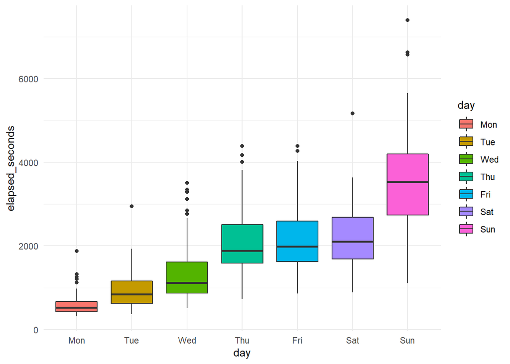

```r
data$day <- factor(data$day, levels = c("Mon", "Tue", "Wed", "Thu", "Fri", "Sat", "Sun"))

ggplot(data, aes(x=day, y=elapsed_seconds, fill = day))+
  geom_boxplot()
```

```r
knitr::kable(data %>%
  group_by("Day of the Week" = day) %>%
  summarize("Fastest Time (in min.)" = round(min(elapsed_seconds)/60,2), "Average Time" = round(mean(elapsed_seconds)/60,2), "Std. dev." = round(sd(elapsed_seconds)/60,2)))
```

| Day of the Week | Fastest Time (in min.) | Average Time | Std. dev. |
| --- | --- | --- | --- |
| Mon | 5.25 | 9.84 | 4.27 |
| Tue | 6.22 | 15.77 | 7.32 |
| Wed | 8.63 | 22.47 | 11.89 |
| Thu | 12.23 | 35.06 | 13.18 |
| Fri | 14.38 | 36.07 | 13.50 |
| Sat | 14.82 | 37.75 | 12.52 |
| Sun | 18.48 | 60.68 | 19.87 |

```r
#add a "week" variable based on puzzle date
data_Mon <- data %>%
  filter(day == "Mon") %>%
  mutate(week = c(1:nrow(data %>% filter(day=="Mon"))))

data_Tue <- data %>%
  filter(day == "Tue") %>%
  mutate(week = c(1:nrow(data %>% filter(day=="Tue"))))

data_Wed <- data %>%
  filter(day == "Wed") %>%
  mutate(week = c(1:nrow(data %>% filter(day=="Wed"))))

data_Thu <- data %>%
  filter(day == "Thu") %>%
  mutate(week = c(1:nrow(data %>% filter(day=="Thu"))))

data_Fri <- data %>%
  filter(day == "Fri") %>%
  mutate(week = c(1:nrow(data %>% filter(day=="Fri"))))

data_Sat <- data %>%
  filter(day == "Sat") %>%
  mutate(week = c(1:nrow(data %>% filter(day=="Sat"))))

data_Sun <- data %>%
  filter(day == "Sun") %>%
  mutate(week = c(1:nrow(data %>% filter(day=="Sun"))))

data <- rbind(data_Mon, data_Tue, data_Wed, data_Thu, data_Fri, data_Sat, data_Sun)
```

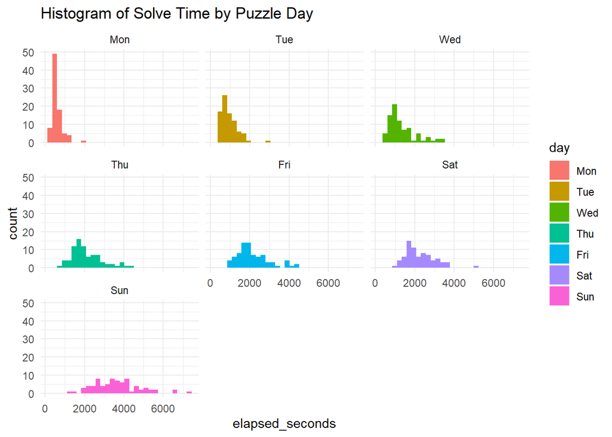

```r
ggplot(data, aes(x=elapsed_seconds, fill = day))+
  geom_histogram()+
  facet_wrap(~day)+
  ggtitle("Histogram of Solve Time by Puzzle Day")
```

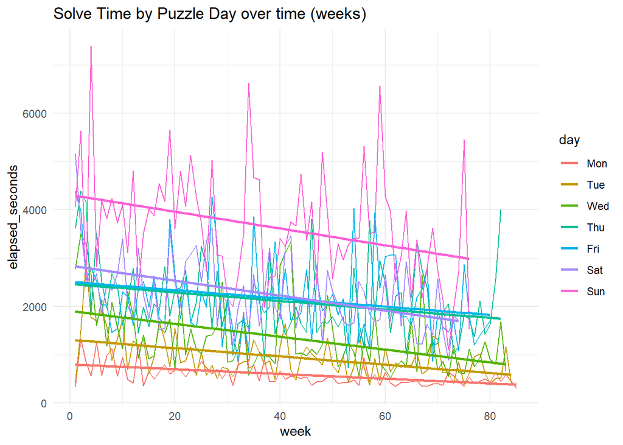

```r
p1<-ggplot(data, aes(x=week, y=elapsed_seconds, color=day))+
  geom_line()+
  geom_smooth(method="lm", se=FALSE)+
  ggtitle("Solve Time by Puzzle Day over time (weeks)")

p1
```

Average solve time appears to decrease as time (the date the puzzle was published) increases, with the sharpest decreases among Sunday puzzles.

# Modeling

## Simple linear model

```r
model1 <- lm(elapsed_seconds ~ week, data=data)
summary(model1)
```

```
##
## Call:
## lm(formula = elapsed_seconds ~ week, data = data)
##
## Residuals:
##     Min      1Q  Median      3Q     Max
## -2027.3  -879.2  -219.4   587.2  5081.1
##
## Coefficients:
##             Estimate Std. Error t value Pr(>|t|)
## (Intercept) 2365.441     98.134    24.1  < 2e-16 ***
## week         -13.124      2.083    -6.3 6.02e-10 ***
## ---
## Signif. codes:  0 '***' 0.001 '**' 0.01 '*' 0.05 '.' 0.1 ' ' 1
##
## Residual standard error: 1158 on 562 degrees of freedom
## Multiple R-squared:  0.06596,    Adjusted R-squared:  0.0643
## F-statistic: 39.69 on 1 and 562 DF,  p-value: 6.021e-10
```

## Random intercepts model + diagnostics

```r
model2 <- lmer(elapsed_seconds ~ week + (1|day), data=data)
summary(model2)
```

```
## Linear mixed model fit by REML. t-tests use Satterthwaite's method [
## lmerModLmerTest]
## Formula: elapsed_seconds ~ week + (1 | day)
##    Data: data
##
## REML criterion at convergence: 9021.9
##
## Scaled residuals:
##     Min      1Q  Median      3Q     Max
## -3.0563 -0.5752 -0.1172  0.3813  4.7970
##
## Random effects:
##  Groups   Name        Variance Std.Dev.
##  day      (Intercept) 990370   995.2
##  Residual             502563   708.9
## Number of obs: 564, groups:  day, 7
##
## Fixed effects:
##             Estimate Std. Error       df t value Pr(>|t|)
## (Intercept) 2295.762    380.915    6.230   6.027  0.00082 ***
## week         -10.554      1.279  556.046  -8.251 1.15e-15 ***
## ---
## Signif. codes:  0 '***' 0.001 '**' 0.01 '*' 0.05 '.' 0.1 ' ' 1
##
## Correlation of Fixed Effects:
##      (Intr)
## week -0.137
```

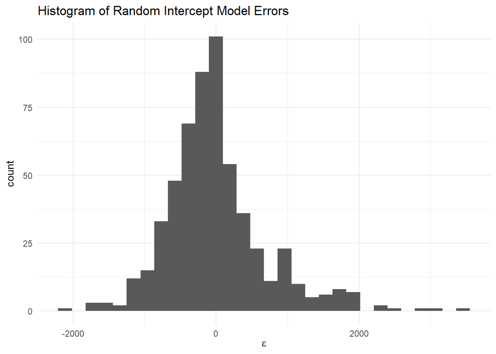

```r
df <- data
df$res <- model2@resp$wtres

ggplot(df, aes(x=res))+
  geom_histogram()+
  xlab(expression(epsilon))+
  ggtitle("Histogram of Random Intercept Model Errors")
```

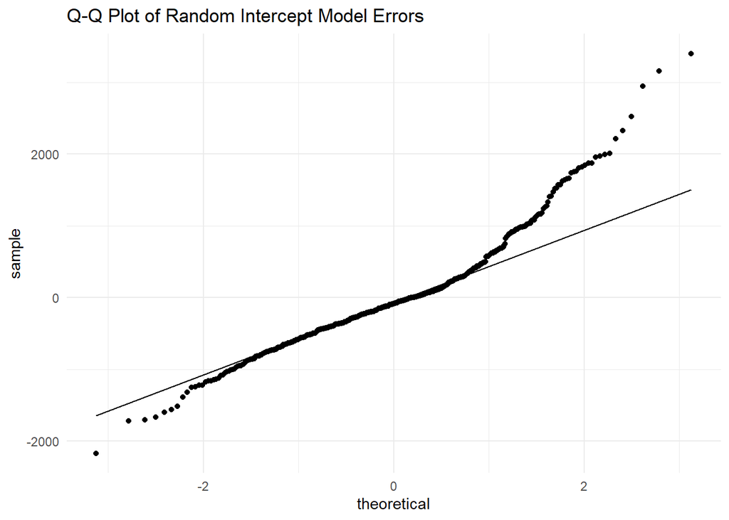

```r
ggplot(df, aes(sample=res))+
  stat_qq()+
  geom_qq_line()+
  ggtitle("Q-Q Plot of Random Intercept Model Errors")
```

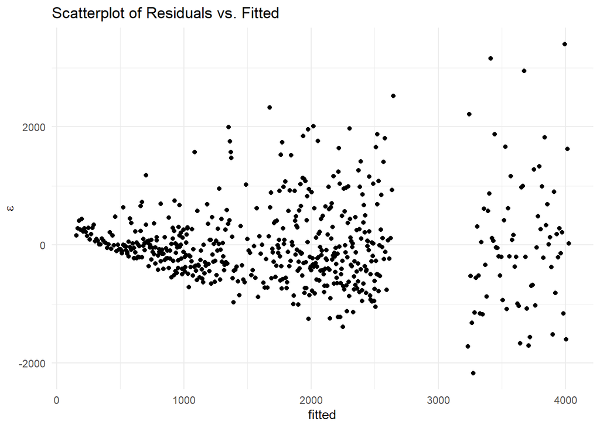

```r
df$fitted <- fitted(model2)

ggplot(df, aes(x=fitted,y=res))+
  geom_point()+
  ylab(expression(epsilon))+
  ggtitle("Scatterplot of Residuals vs. Fitted")
```

## Random slopes and intercepts model

```r
model3 <- lmer(elapsed_seconds ~ week + (1+day|day), data=data)
summary(model3)
```

```
## Linear mixed model fit by REML. t-tests use Satterthwaite's method [
## lmerModLmerTest]
## Formula: elapsed_seconds ~ week + (1 + day | day)
##    Data: data
##
## REML criterion at convergence: 9011.7
##
## Scaled residuals:
##     Min      1Q  Median      3Q     Max
## -3.0662 -0.5743 -0.1081  0.3774  4.7882
##
## Random effects:
##  Groups   Name        Variance Std.Dev. Corr
##  day      (Intercept) 2384918  1544.3
##           dayTue       156237   395.3   -0.92
##           dayWed       800621   894.8   -0.92  0.98
##           dayThu      2384918  1544.3   -1.00  0.92  0.92
##           dayFri      2384950  1544.3   -1.00  0.92  0.92  1.00
##           daySat      2346310  1531.8   -1.00  0.92  0.92  1.00  1.00
##           daySun       867156   931.2   -0.40  0.22  0.21  0.40  0.40  0.39
##  Residual              501742   708.3
## Number of obs: 564, groups:  day, 7
##
## Fixed effects:
##             Estimate Std. Error       df t value Pr(>|t|)
## (Intercept) 2593.190     68.793   19.017   37.70  < 2e-16 ***
## week         -10.610      1.277  558.958   -8.31 7.29e-16 ***
## ---
## Signif. codes:  0 '***' 0.001 '**' 0.01 '*' 0.05 '.' 0.1 ' ' 1
##
## Correlation of Fixed Effects:
##      (Intr)
## week -0.741
## convergence code: 0
## boundary (singular) fit: see ?isSingular
```

## Summary of Results (AIC and BIC)

```r
AIC(model1, model2, model3)
```

```
##        df      AIC
## model1  3 9562.263
## model2  4 9029.933
## model3 31 9073.654
```

```r
BIC(model1, model2, model3)
```

```
##        df      BIC
## model1  3 9575.269
## model2  4 9047.274
## model3 31 9208.041
```

# Does ordering puzzles by the date I solved them make a difference in the goodness of fit?

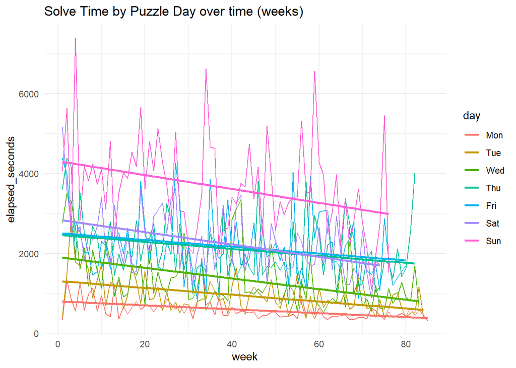

```r
#sort by solved date
data <- data[order(data$solve_date),]

#add "week2" variable (chronological order of solved date)
data_Mon <- data %>%
  filter(day == "Mon") %>%
  mutate(week2 = c(1:nrow(data %>% filter(day=="Mon"))))

data_Tue <- data %>%
  filter(day == "Tue") %>%
  mutate(week2 = c(1:nrow(data %>% filter(day=="Tue"))))

data_Wed <- data %>%
  filter(day == "Wed") %>%
  mutate(week2 = c(1:nrow(data %>% filter(day=="Wed"))))

data_Thu <- data %>%
  filter(day == "Thu") %>%
  mutate(week2 = c(1:nrow(data %>% filter(day=="Thu"))))

data_Fri <- data %>%
  filter(day == "Fri") %>%
  mutate(week2 = c(1:nrow(data %>% filter(day=="Fri"))))

data_Sat <- data %>%
  filter(day == "Sat") %>%
  mutate(week2 = c(1:nrow(data %>% filter(day=="Sat"))))

data_Sun <- data %>%
  filter(day == "Sun") %>%
  mutate(week2 = c(1:nrow(data %>% filter(day=="Sun"))))

data2 <- rbind(data_Mon, data_Tue, data_Wed, data_Thu, data_Fri, data_Sat, data_Sun)

p2<-ggplot(data2, aes(x=week2, y=elapsed_seconds, color=day))+
  geom_line()+
  geom_smooth(method="lm", se=FALSE)+
  ggtitle("Solve Time by Puzzle Day over time (weeks)")

p1
```

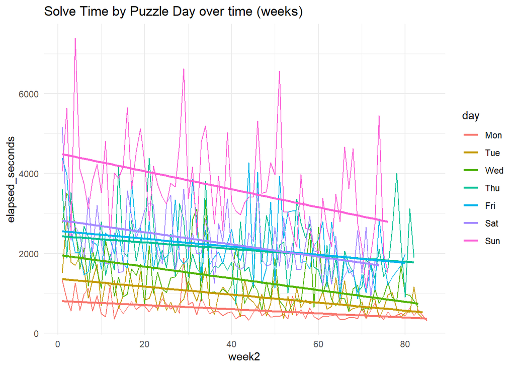

```r
p2
```

The two “week” variables don’t appear to differ that much. Let’s see whether models based on the `week2` variable have better fits.

## Simple linear model

```r
model4 <- lm(elapsed_seconds ~ week2, data=data2)
summary(model4)
```

```
##
## Call:
## lm(formula = elapsed_seconds ~ week2, data = data2)
##
## Residuals:
##     Min      1Q  Median      3Q     Max
## -1868.5  -844.5  -252.2   647.3  5037.8
##
## Coefficients:
##             Estimate Std. Error t value Pr(>|t|)
## (Intercept) 2413.391     97.485  24.757  < 2e-16 ***
## week2        -14.297      2.069  -6.909 1.33e-11 ***
## ---
## Signif. codes:  0 '***' 0.001 '**' 0.01 '*' 0.05 '.' 0.1 ' ' 1
##
## Residual standard error: 1151 on 562 degrees of freedom
## Multiple R-squared:  0.07828,    Adjusted R-squared:  0.07664
## F-statistic: 47.73 on 1 and 562 DF,  p-value: 1.33e-11
```

## Random intercepts model

```r
model5 <- lmer(elapsed_seconds ~ week2 + (1|day), data=data2)
summary(model5)
```

```
## Linear mixed model fit by REML. t-tests use Satterthwaite's method [
## lmerModLmerTest]
## Formula: elapsed_seconds ~ week2 + (1 | day)
##    Data: data2
##
## REML criterion at convergence: 9005.6
##
## Scaled residuals:
##     Min      1Q  Median      3Q     Max
## -3.0621 -0.6211 -0.1170  0.3913  4.8091
##
## Random effects:
##  Groups   Name        Variance Std.Dev.
##  day      (Intercept) 986610   993.3
##  Residual             488047   698.6
## Number of obs: 564, groups:  day, 7
##
## Fixed effects:
##             Estimate Std. Error       df t value Pr(>|t|)
## (Intercept) 2343.908    380.072    6.225   6.167 0.000726 ***
## week2        -11.734      1.261  556.045  -9.309  < 2e-16 ***
## ---
## Signif. codes:  0 '***' 0.001 '**' 0.01 '*' 0.05 '.' 0.1 ' ' 1
##
## Correlation of Fixed Effects:
##       (Intr)
## week2 -0.135
```

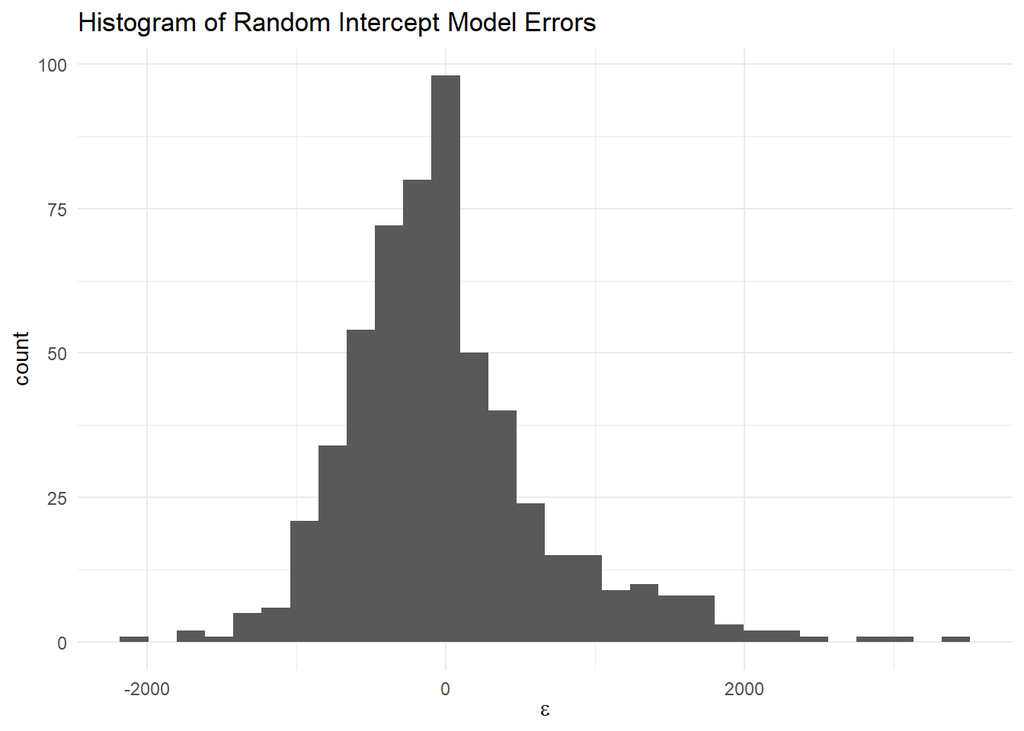

```r
df3 <- data2
df3$res <- model5@resp$wtres

ggplot(df3, aes(x=res))+
  geom_histogram()+
  xlab(expression(epsilon))+
  ggtitle("Histogram of Random Intercept Model Errors")
```

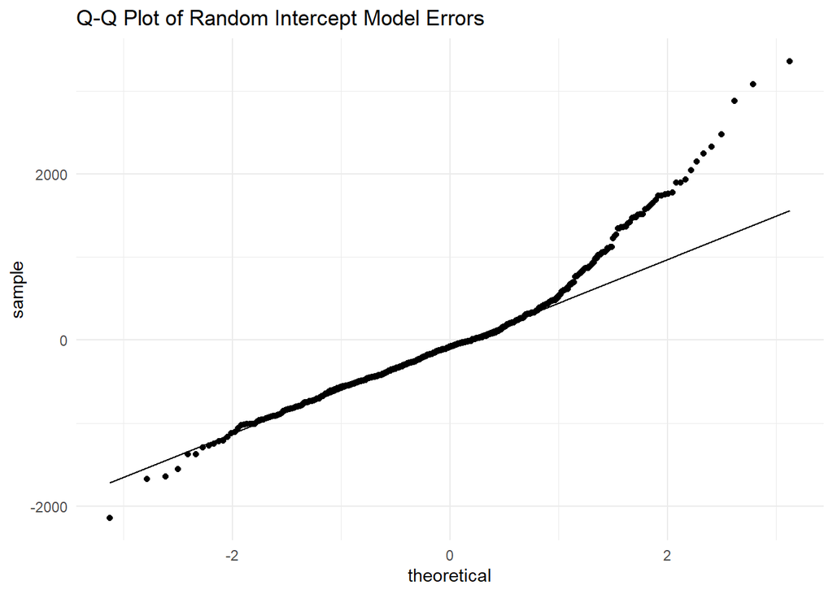

```r
ggplot(df3, aes(sample=res))+
  stat_qq()+
  geom_qq_line()+
  ggtitle("Q-Q Plot of Random Intercept Model Errors")
```

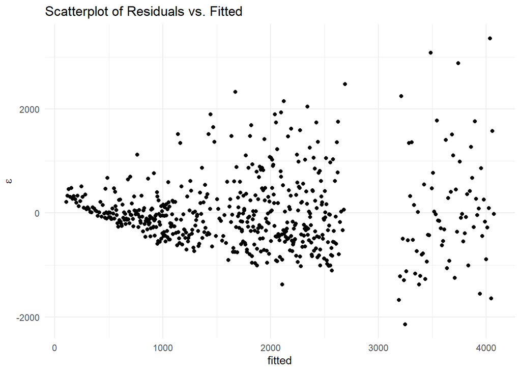

```r
df3$fitted <- fitted(model5)

ggplot(df3, aes(x=fitted,y=res))+
  geom_point()+
  ylab(expression(epsilon))+
  ggtitle("Scatterplot of Residuals vs. Fitted")
```

## Random slopes and intercepts model

```r
model6 <- lmer(elapsed_seconds ~ week2 + (1+day|day), data=data2)
summary(model6)
```

```
## Linear mixed model fit by REML. t-tests use Satterthwaite's method [
## lmerModLmerTest]
## Formula: elapsed_seconds ~ week2 + (1 + day | day)
##    Data: data2
##
## REML criterion at convergence: 8995.2
##
## Scaled residuals:
##     Min      1Q  Median      3Q     Max
## -3.0721 -0.6142 -0.1154  0.3861  4.8005
##
## Random effects:
##  Groups   Name        Variance Std.Dev. Corr
##  day      (Intercept) 2349617  1532.8
##           dayTue       258635   508.6   -0.76
##           dayWed      1860783  1364.1   -0.85  0.45
##           dayThu      2349366  1532.8   -1.00  0.76  0.85
##           dayFri      2350019  1533.0   -1.00  0.76  0.85  1.00
##           daySat      2349417  1532.8   -1.00  0.76  0.85  1.00  1.00
##           daySun       253530   503.5   -0.31 -0.27  0.70  0.31  0.31  0.31
##  Residual              487214   698.0
## Number of obs: 564, groups:  day, 7
##
## Fixed effects:
##             Estimate Std. Error       df t value Pr(>|t|)
## (Intercept) 2640.966     67.637  191.013   39.05   <2e-16 ***
## week2        -11.789      1.258  559.084   -9.37   <2e-16 ***
## ---
## Signif. codes:  0 '***' 0.001 '**' 0.01 '*' 0.05 '.' 0.1 ' ' 1
##
## Correlation of Fixed Effects:
##       (Intr)
## week2 -0.743
## convergence code: 0
## boundary (singular) fit: see ?isSingular
```

## Summary of All Results (AIC and BIC)

```r
AIC(model1, model2, model3, model4, model5, model6)
```

```
##        df      AIC
## model1  3 9562.263
## model2  4 9029.933
## model3 31 9073.654
## model4  3 9554.776
## model5  4 9013.614
## model6 31 9057.225
```

```r
BIC(model1, model2, model3, model4, model5, model6)
```

```
##        df      BIC
## model1  3 9575.269
## model2  4 9047.274
## model3 31 9208.041
## model4  3 9567.781
## model5  4 9030.954
## model6 31 9191.612
```

```r
summary(model5)
```

```
## Linear mixed model fit by REML. t-tests use Satterthwaite's method [
## lmerModLmerTest]
## Formula: elapsed_seconds ~ week2 + (1 | day)
##    Data: data2
##
## REML criterion at convergence: 9005.6
##
## Scaled residuals:
##     Min      1Q  Median      3Q     Max
## -3.0621 -0.6211 -0.1170  0.3913  4.8091
##
## Random effects:
##  Groups   Name        Variance Std.Dev.
##  day      (Intercept) 986610   993.3
##  Residual             488047   698.6
## Number of obs: 564, groups:  day, 7
##
## Fixed effects:
##             Estimate Std. Error       df t value Pr(>|t|)
## (Intercept) 2343.908    380.072    6.225   6.167 0.000726 ***
## week2        -11.734      1.261  556.045  -9.309  < 2e-16 ***
## ---
## Signif. codes:  0 '***' 0.001 '**' 0.01 '*' 0.05 '.' 0.1 ' ' 1
##
## Correlation of Fixed Effects:
##       (Intr)
## week2 -0.135
```

Model 5 – random intercepts with solved week as the explanatory variable – has the best fit. According to Model 5, I decrease my average puzzle solve time by -11.734 seconds each week.

# Models for each day of the week because I’m compulsive

```r
fitmon <- lm(elapsed_seconds ~ week2, data=filter(data2, day=="Mon"))
fittue <- lm(elapsed_seconds ~ week2, data=filter(data2, day=="Tue"))
fitwed <- lm(elapsed_seconds ~ week2, data=filter(data2, day=="Wed"))
fitthu <- lm(elapsed_seconds ~ week2, data=filter(data2, day=="Thu"))
fitfri <- lm(elapsed_seconds ~ week2, data=filter(data2, day=="Fri"))
fitsat <- lm(elapsed_seconds ~ week2, data=filter(data2, day=="Sat"))
fitsun <- lm(elapsed_seconds ~ week2, data=filter(data2, day=="Sun"))

tbl_mon <- tbl_regression(fitmon, intercept=TRUE)
tbl_tue <- tbl_regression(fittue, intercept=TRUE)
tbl_wed <- tbl_regression(fitwed, intercept=TRUE)
tbl_thu <- tbl_regression(fitthu, intercept=TRUE)
tbl_fri <- tbl_regression(fitfri, intercept=TRUE)
tbl_sat <- tbl_regression(fitsat, intercept=TRUE)
tbl_sun <- tbl_regression(fitsun, intercept=TRUE)

tbl_merge(tbls = list(tbl_mon, tbl_tue, tbl_wed, tbl_thu, tbl_fri, tbl_sat, tbl_sun), tab_spanner=c("**Mon**", "**Tue**", "**Wed**", "**Thu**", "**Fri**", "**Sat**", "**Sun**"))
```

| **Characteristic** | **Mon** **Beta** | **Mon** **95% CI**<sup>1</sup> | **Mon** **p-value** | **Tue** **Beta** | **Tue** **95% CI**<sup>1</sup> | **Tue** **p-value** | **Wed** **Beta** | **Wed** **95% CI**<sup>1</sup> | **Wed** **p-value** | **Thu** **Beta** | **Thu** **95% CI**<sup>1</sup> | **Thu** **p-value** | **Fri** **Beta** | **Fri** **95% CI**<sup>1</sup> | **Fri** **p-value** | **Sat** **Beta** | **Sat** **95% CI**<sup>1</sup> | **Sat** **p-value** | **Sun** **Beta** | **Sun** **95% CI**<sup>1</sup> | **Sun** **p-value** |
| --- | --- | --- | --- | --- | --- | --- | --- | --- | --- | --- | --- | --- | --- | --- | --- | --- | --- | --- | --- | --- | --- |
| (Intercept) | 814 | 717, 911 | <0.001 | 1,371 | 1,210, 1,532 | <0.001 | 1,965 | 1,690, 2,240 | <0.001 | 2,438 | 2,096, 2,781 | <0.001 | 2,570 | 2,219, 2,921 | <0.001 | 2,839 | 2,521, 3,157 | <0.001 | 4,509 | 4,006, 5,013 | <0.001 |
| week2 | -5.2 | -7.2, -3.2 | <0.001 | -10 | -13, -6.7 | <0.001 | -15 | -20, -9.0 | <0.001 | -8.1 | -15, -0.90 | 0.028 | -10 | -18, -2.5 | 0.010 | -15 | -23, -7.9 | <0.001 | -23 | -34, -11 | <0.001 |

<sup>*1*</sup> CI = Confidence Interval

My largest improvement each week is -23 seconds for Sunday puzzles, followed by Wednesday and Saturday (Wednesday has a slightly tighter confidence interval).

### Visregs

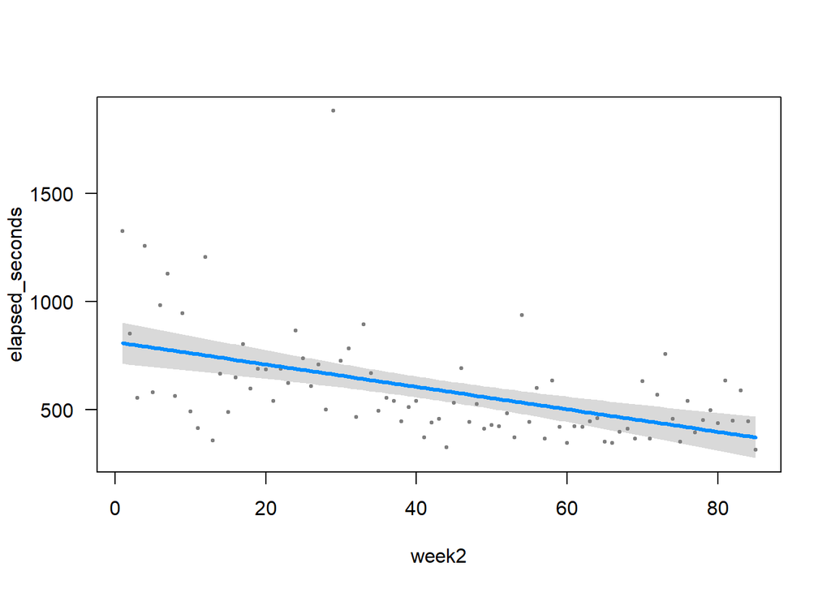

```r
visreg(fitmon)
```

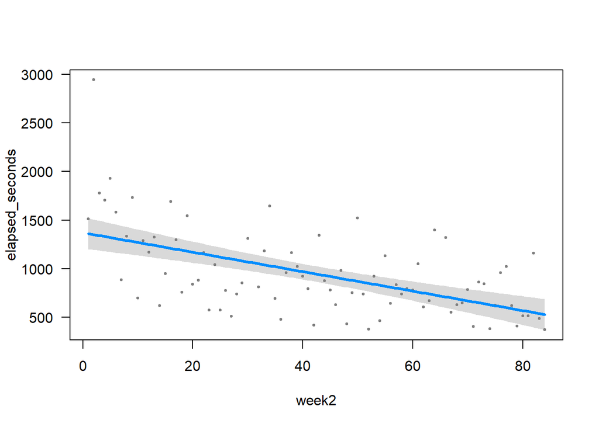

```r
visreg(fittue)
```

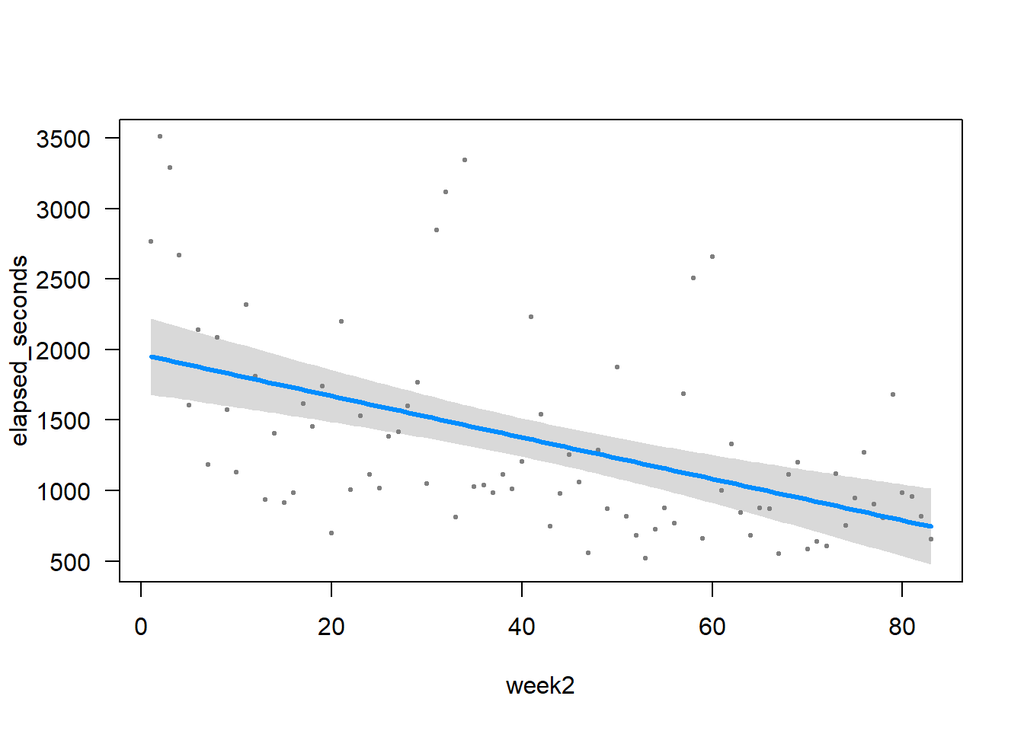

```r
visreg(fitwed)
```

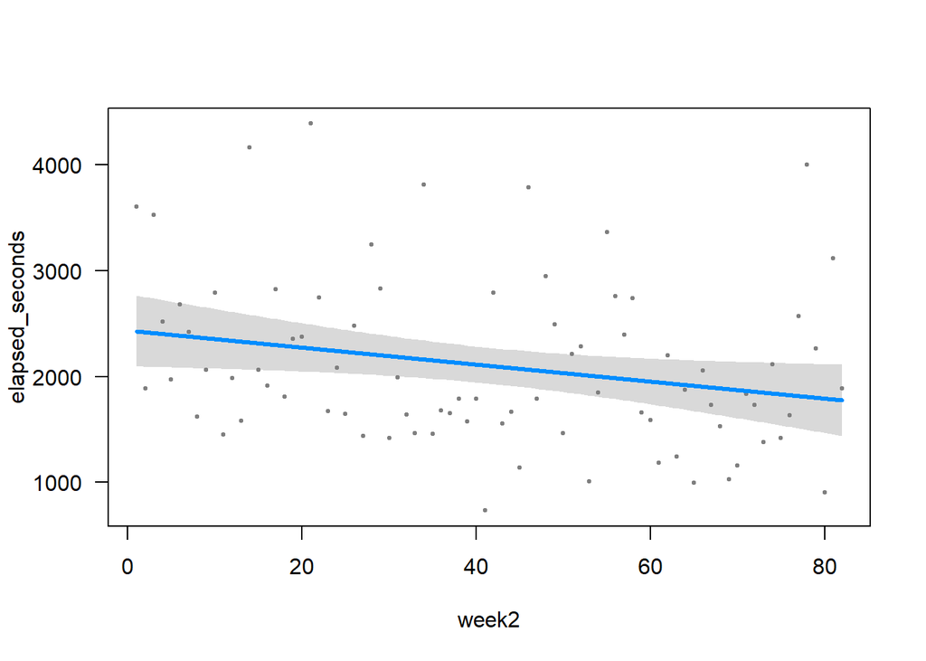

```r
visreg(fitthu)
```

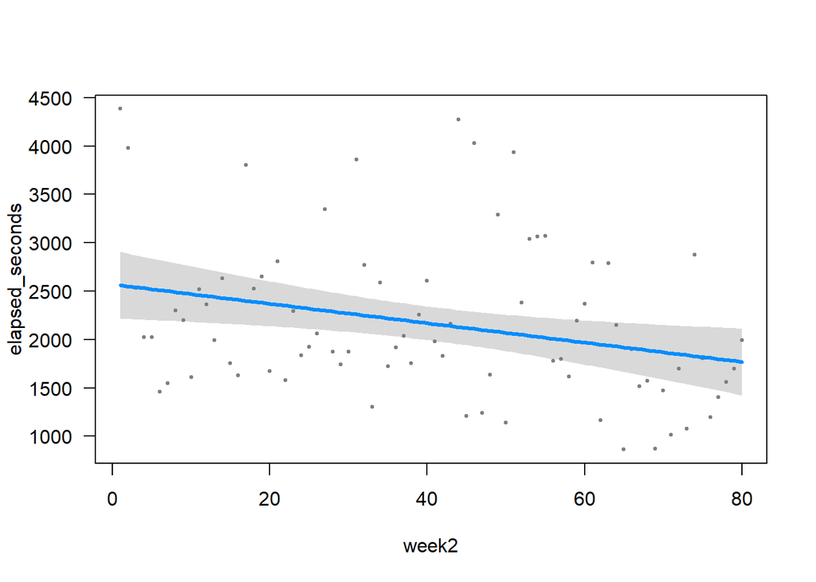

```r
visreg(fitfri)
```

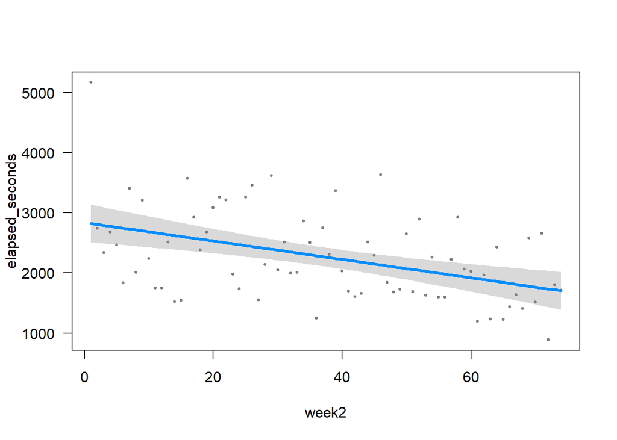

```r
visreg(fitsat)
```

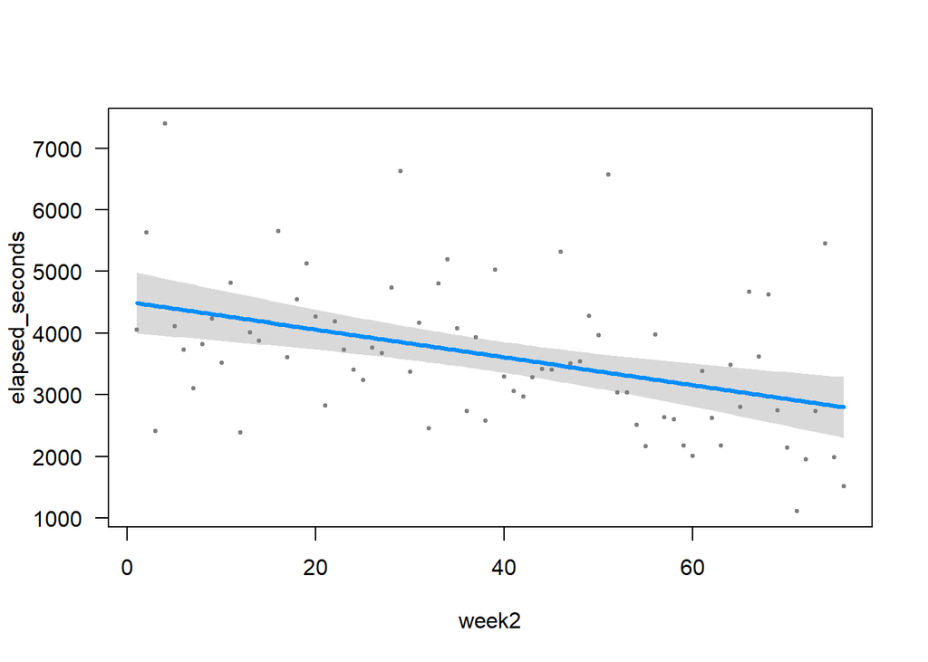

```r
visreg(fitsun)
```

### Linear Regression Diagnostics

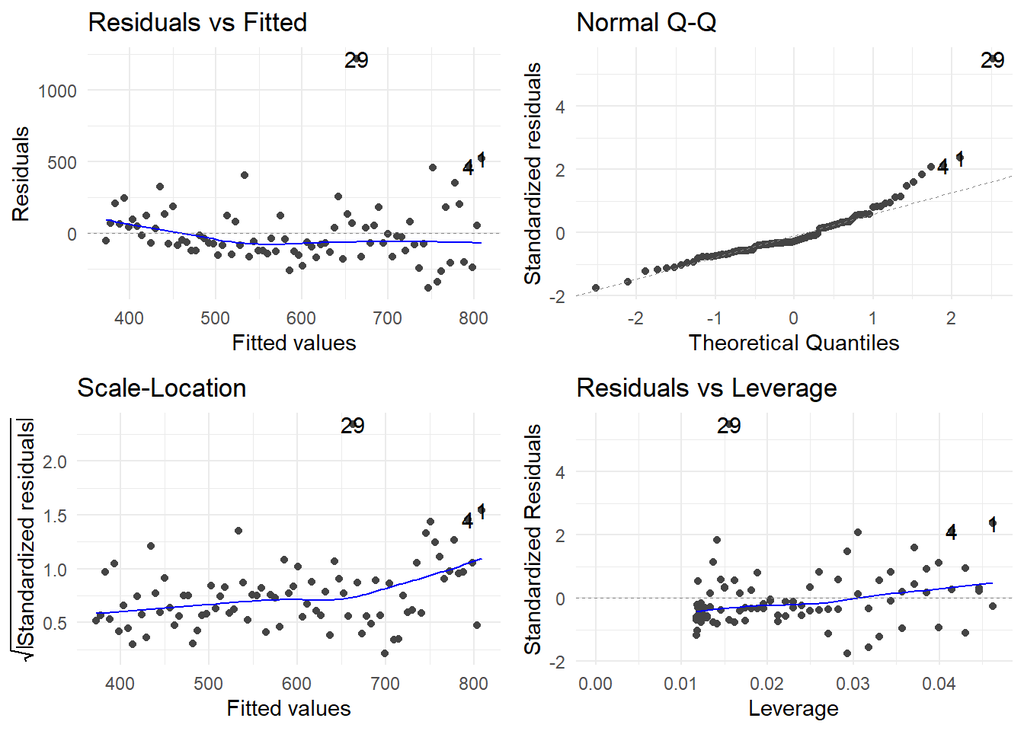

```r
autoplot(fitmon)
```

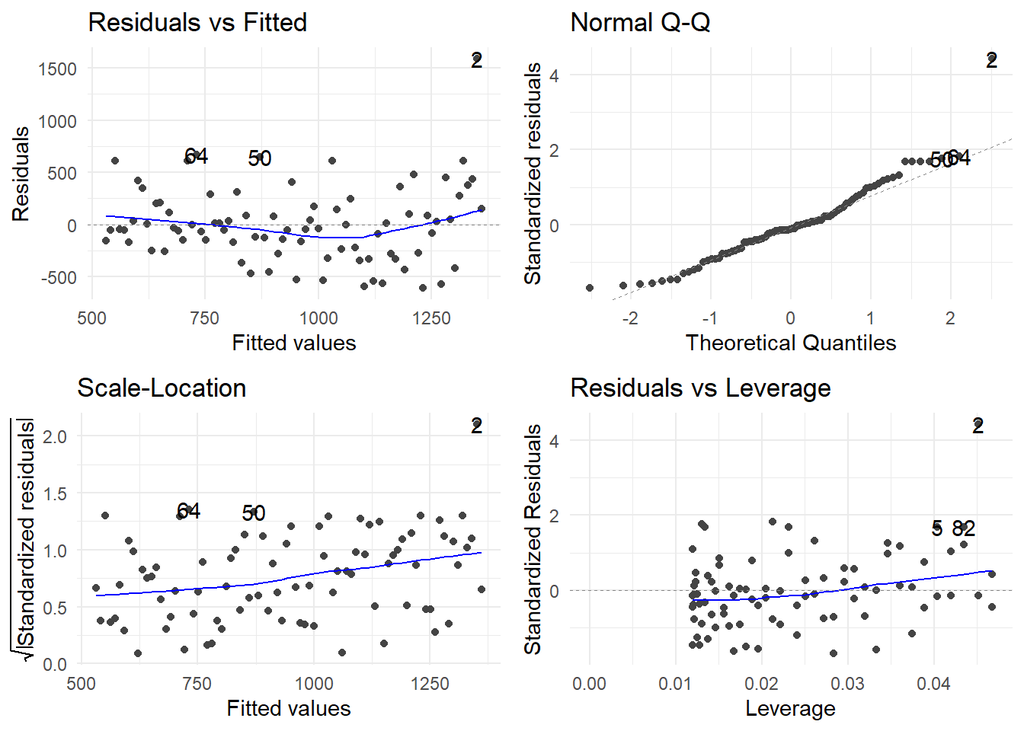

```r
autoplot(fittue)
```

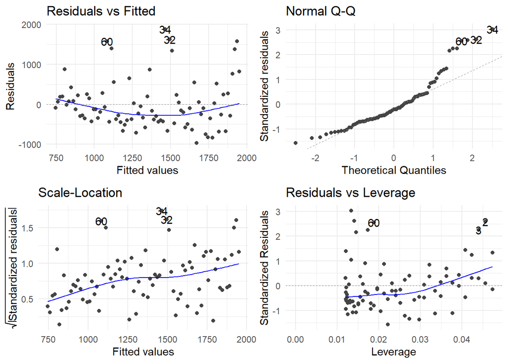

```r
autoplot(fitwed)
```

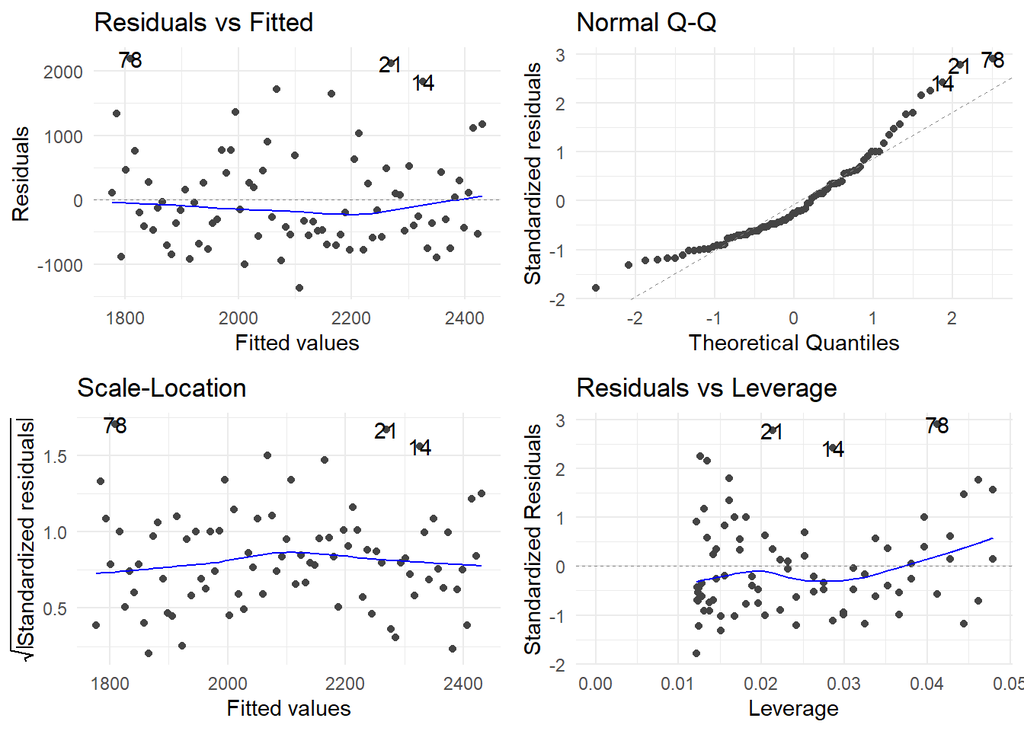

```r
autoplot(fitthu)
```

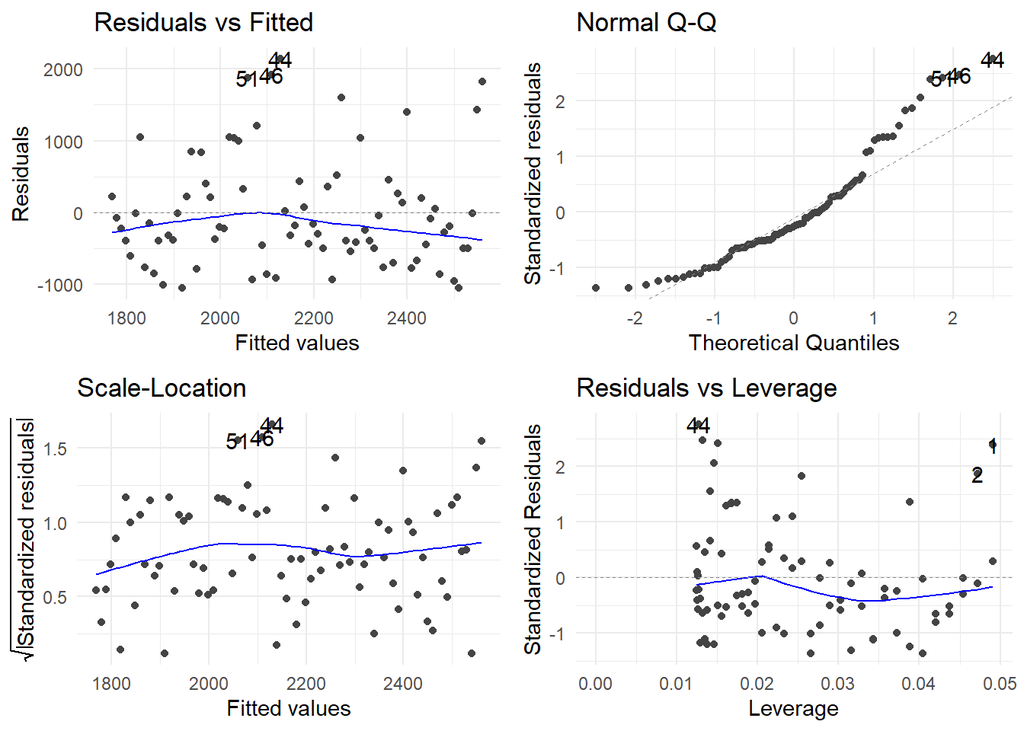

```r
autoplot(fitfri)
```

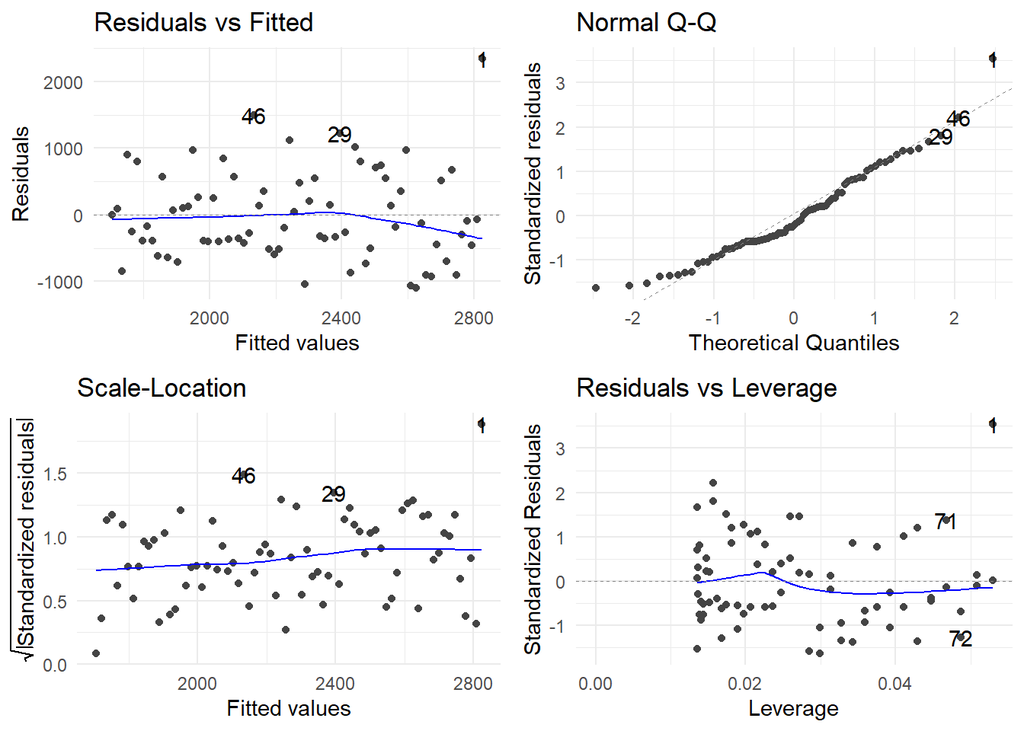

```r
autoplot(fitsat)
```

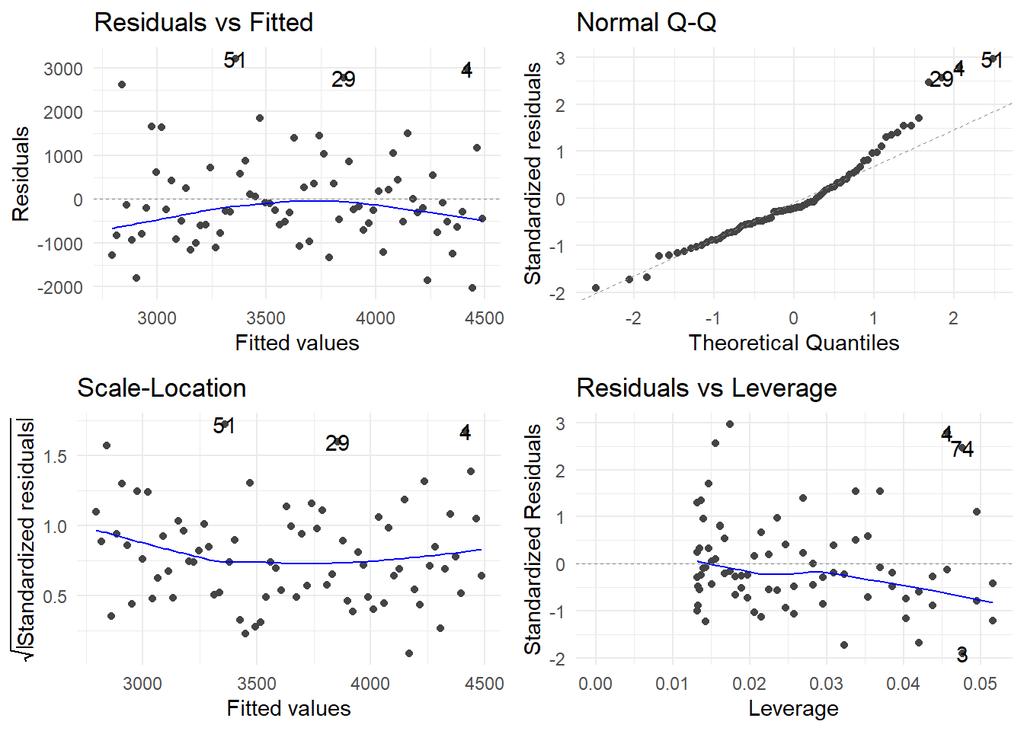

```r
autoplot(fitsun)
```